# Exercise 2 - Regression

# Plotting Residuals versus Fitted Values, Normal QQ-Plot, and Residuals vs Leverage

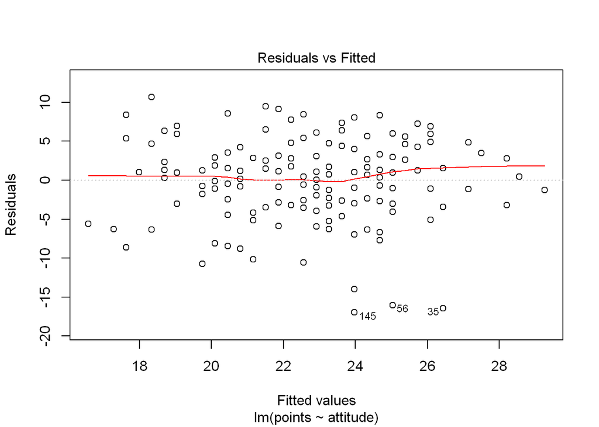

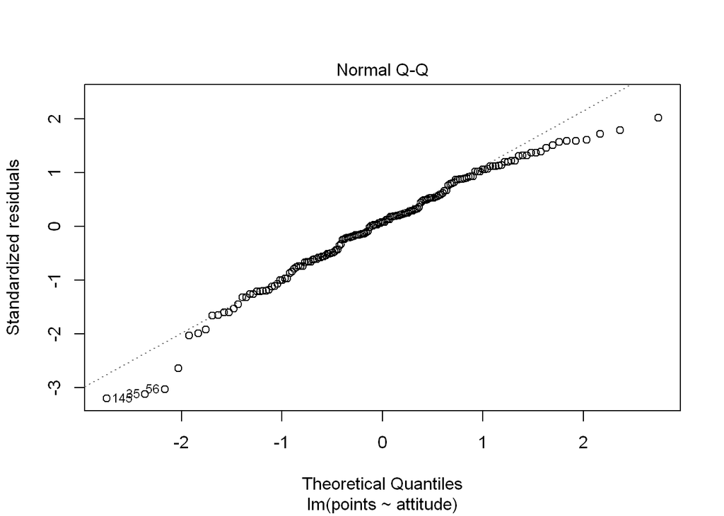

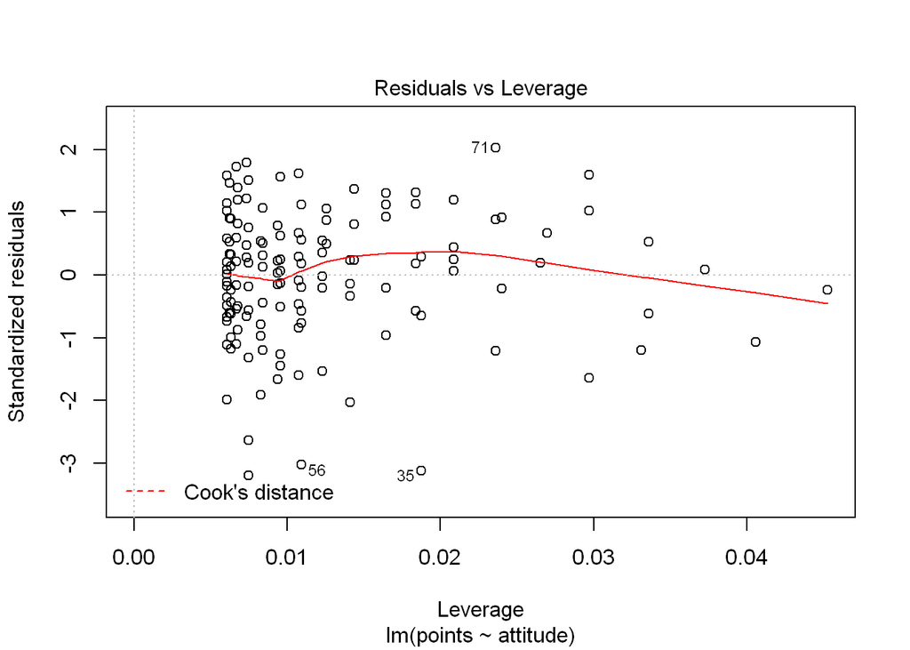

```r
plot (my_model2, which = c(1, 2, 5))
```

# In the first plot we can see that the red line is close to 0, indicating that the fit of the model does not depend on the amount of points: it works for high and low amounts of points

# The Q-Q-Plot show us that for the highest and lowest quantiles (below -2 and above 2), the prediction is not accurate, indicating that a linear model might not fit the data best. However, for the majority of data points, the linear model fits well

# The residuals vs leverage graph shows that there are no outliers that heavily influence our regression model; the red line is rather flat.